# *Clasificador CNN para detección de casos Covid-19 con radiografías*

La motivación para realizar este proyecto es la utilidad que se le puede dar a Machine Learning, en concreto la rama de Deep Learning, en el ámbito de la medicina.

La situación de estos dos últimos años ha sido muy grave debido a la pandemia del Covid-19, por lo que se han realizado pruebas con varias redes convolucionales (CNN) para intentar detectar anomalias en radiografías pulmonares de seres humanos y de esta manera poder clasificar casos de pacientes afectados por Covid-19.

A grosso modo, las redes convolucionales son un tipo de redes neuronales artificiales donde las "neuronas" de la CNN intentan imitar el comportamiento de las neuronas de un cerebro biológico humano.

# Preparación de datos (Procesamiento de imágenes)

Se ha selecciondo un dataset que contiene alrededor de 400 radiografías, con el objetivo de que el tiempo de ejecución no se demore demasiado, y se puedan realizar más combinaciones de parámetros, funciones de pérdida, optimizadores, para ir mejorando modelos y aprendiendo sobre su funcionamiento.

```python
# Se monta el drive para cargar el dataset con las imágenes
from google.colab import drive
drive.mount('/content/drive')
%cd '/content/drive/MyDrive/colab_notebooks/Datos_no_estructurados/practica_imagen'
!pwd
!ls
```

Al usar imágenes en blanco y negro (cambiando las imágenes a escala de grises) se pierde entre un 1 y un 3 % de rendimiento en tareas como el reconocimiento de objetos.

Existe una peculiaridad en esta clase, este procesamiento de imágenes genera dos pickles, que contienen las imágenes de entrenamiento y test, la CNN pasará por todas las imágenes del entrenamiento una sola vez, por lo que si es necesario reentrar el modelo el tiempo de reejecución será menor (en este caso, no tiene ninguna utilidad puesto que el dataset es muy pequeño).

```python
try:
    import pickle
    import numpy as np
    import tensorflow as tf
    from tensorflow.keras import datasets, layers, models
    from keras.layers import Dense, Dropout, Flatten
    import matplotlib.pyplot as plt
    import os, sys
    from google.colab.patches import cv2_imshow
    import numpy as np
    import cv2 # OpenCV-Python
    %matplotlib inline
    import matplotlib.pyplot as plt
    print("Library Loaded Successfully ..........")
except:
    print("Library not Found ! ")


class MasterImage(object):

    def __init__(self,PATH='', IMAGE_SIZE = 50):
        self.PATH = PATH
        self.IMAGE_SIZE = IMAGE_SIZE

        self.image_data = []
        self.x_data = []
        self.y_data = []
        self.CATEGORIES = []

        # This will get List of categories
        self.list_categories = []

    def get_categories(self):
        for path in os.listdir(self.PATH):
            if '.DS_Store' in path:
                pass
            else:
                self.list_categories.append(path)
        print("Found Categories ",self.list_categories,'\n')
        return self.list_categories

    def Process_Image(self):
        try:
            """
            Return Numpy array of image
            :return: X_Data, Y_Data
            """
            self.CATEGORIES = self.get_categories()
            for categories in self.CATEGORIES:                                                  # Iterate over categories

                train_folder_path = os.path.join(self.PATH, categories)                         # Folder Path
                class_index = self.CATEGORIES.index(categories)                                 # this will get index for classification

                for img in os.listdir(train_folder_path):                                       # This will iterate in the Folder
                    new_path = os.path.join(train_folder_path, img)                             # image Path

                    try:        # if any image is corrupted
                        image_data_temp = cv2.imread(new_path,cv2.IMREAD_GRAYSCALE)                 # Read Image as numbers
                        image_temp_resize = cv2.resize(image_data_temp,(self.IMAGE_SIZE,self.IMAGE_SIZE))
                        self.image_data.append([image_temp_resize,class_index])
                    except:
                        pass

            data = np.asanyarray(self.image_data)

            # Iterate over the Data
            for x in data:
                self.x_data.append(x[0])        # Get the X_Data
                self.y_data.append(x[1])        # get the label

            X_Data = np.asarray(self.x_data) / (255.0)      # Normalize Data
            Y_Data = np.asarray(self.y_data)

            # reshape x_Data

            X_Data = X_Data.reshape(-1, self.IMAGE_SIZE, self.IMAGE_SIZE, 3)

            return X_Data, Y_Data
        except:
            print("Failed to run Function Process Image ")

    def pickle_image(self):

        """
        :return: None Creates a Pickle Object of DataSet
        """
        # Call the Function and Get the Data
        X_Data,Y_Data = self.Process_Image()

        # Write the Entire Data into a Pickle File
        pickle_out = open('X_Data','wb')
        pickle.dump(X_Data, pickle_out)
        pickle_out.close()

        # Write the Y Label Data
        pickle_out = open('Y_Data', 'wb')
        pickle.dump(Y_Data, pickle_out)
        pickle_out.close()

        print("Pickled Image Successfully ")
        return X_Data,Y_Data

    def load_dataset(self):

        try:
            # Read the Data from Pickle Object
            X_Temp = open('X_Data','rb')
            X_Data = pickle.load(X_Temp)

            Y_Temp = open('Y_Data','rb')
            Y_Data = pickle.load(Y_Temp)

            print('Reading Dataset from PIckle Object')

            return X_Data,Y_Data

        except:
            print('Could not Found Pickle File ')
            print('Loading File and Dataset  ..........')

            X_Data,Y_Data = self.pickle_image()
            return X_Data,Y_Data


if __name__ == "__main__":
    path = '/content/drive/MyDrive/colab_notebooks/Datos_no_estructurados/practica_imagen/fotos/Covid19-dataset/train'
    a = MasterImage(PATH=path,
                    IMAGE_SIZE=50)

    path2 = '/content/drive/MyDrive/colab_notebooks/Datos_no_estructurados/practica_imagen/fotos/Covid19-dataset/test'
    b = MasterImage(PATH=path2,
                    IMAGE_SIZE=50)

    (train_images, train_labels) = a.load_dataset()
    (test_images, test_labels) = b.load_dataset()

    print(train_images.shape)
    print(test_images.shape)
```

[output not shown]

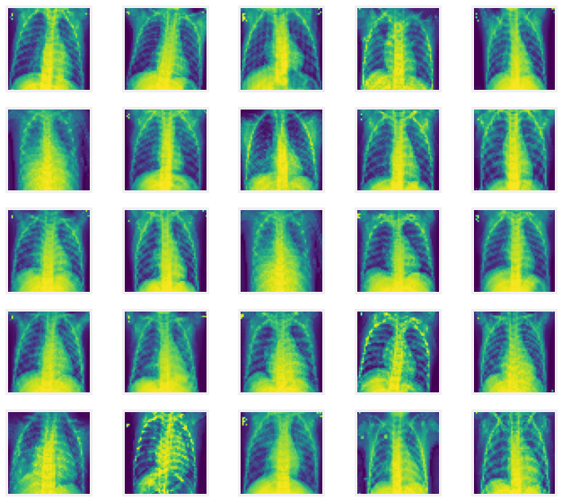

```python
# Representación de imágenes en RGB
class_names = ['Covid','Normal']

plt.figure(figsize=(10,10))
for i in range(25):
    plt.subplot(5,5,i+1)
    plt.xticks([])
    plt.yticks([])
    plt.grid(False)
    plt.imshow(train_images[i].squeeze())
plt.show()
```

# Construcción de la red convolucional

La primera iteración de la CNN tiene una capa convolucional 2D compuesta por 32 filtros de tamaño 3x3, con una función de activación sigmoidal. Le añadimos una capa Dense, con 64 nodos, para que las neuronas reciban inputs de todas las neuronas de la capa anterior.

El número de inputs en la capa Flatten, es igual al producto de los outputs de la capa convolucional 2D (48x48x32), siendo 32 los filtros de la primera y última capa convolucional. Como la única función de la capa flatten es calcular los parámetros de la salida, y no tiene nada que aprender, no tiene ningún parámetros.

El número de episodios empleados para el entrenamiento de las CNN es de 20 episodios, es un número bajo teniendo en cuenta que las CNN suelen requerir muchos mas episodios para su entrenamiento. Se utilizan 20 episodios puesto que no se necesitan más dado el poco volumen de imágenes de las que se disponen.

```python
model_1 = models.Sequential()
model_1.add(layers.Conv2D(32, (3, 3), activation='sigmoid', input_shape=(50, 50, 1)))
```

```python
model_1.add(layers.Flatten())
model_1.add(layers.Dense(64, activation='relu'))
```

```python
model_1.summary()
```

```
Model: "sequential_5"
_________________________________________________________________
 Layer (type)                Output Shape              Param #
=================================================================
 conv2d_9 (Conv2D)           (None, 48, 48, 32)        320

 flatten_4 (Flatten)         (None, 73728)             0

 dense_6 (Dense)             (None, 64)                4718656

=================================================================
Total params: 4,718,976
Trainable params: 4,718,976
Non-trainable params: 0
_________________________________________________________________
```

```python
model_1.compile(optimizer='SGD',
              loss=tf.keras.losses.Poisson(),
              metrics=['accuracy'])

history_1 = model_1.fit(train_images, train_labels, epochs=20,
                    validation_data=(test_images, test_labels))
```

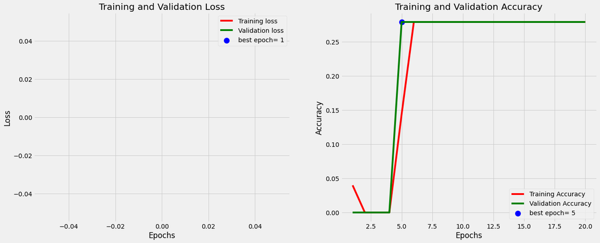

```python
def tr_plot(tr_data, start_epoch):
  #Plot the training and validation data
  tacc=tr_data.history['accuracy']
  tloss=tr_data.history['loss']
  vacc=tr_data.history['val_accuracy']
  vloss=tr_data.history['val_loss']
  Epoch_count=len(tacc)+ start_epoch
  Epochs=[]
  for i in range (start_epoch ,Epoch_count):
    Epochs.append(i+1)
  index_loss=np.argmin(vloss)# this is the epoch with the lowest validation loss
  val_lowest=vloss[index_loss]
  index_acc=np.argmax(vacc)
  acc_highest=vacc[index_acc]
  plt.style.use('fivethirtyeight')
  sc_label='best epoch= '+ str(index_loss+1 +start_epoch)
  vc_label='best epoch= '+ str(index_acc + 1+ start_epoch)
  fig,axes=plt.subplots(nrows=1, ncols=2, figsize=(20,8))
  axes[0].plot(Epochs,tloss, 'r', label='Training loss')
  axes[0].plot(Epochs,vloss,'g',label='Validation loss' )
  axes[0].scatter(index_loss+1 +start_epoch,val_lowest, s=150, c= 'blue', label=sc_label)
  axes[0].set_title('Training and Validation Loss')
  axes[0].set_xlabel('Epochs')
  axes[0].set_ylabel('Loss')
  axes[0].legend()
  axes[1].plot (Epochs,tacc,'r',label= 'Training Accuracy')
  axes[1].plot (Epochs,vacc,'g',label= 'Validation Accuracy')
  axes[1].scatter(index_acc+1 +start_epoch,acc_highest, s=150, c= 'blue', label=vc_label)
  axes[1].set_title('Training and Validation Accuracy')
  axes[1].set_xlabel('Epochs')
  axes[1].set_ylabel('Accuracy')
  axes[1].legend()
  plt.tight_layout
  plt.show()

tr_plot(history_1,0)
```

Los resultados que se obtienen después de la primera iteración de la CNN dejan claro que la función de perdida Poisson no funciona de manera correcta puesto que el accuracy es muy bajo.

Segunda iteración del modelo: En la segunda iteración del modelo, vamos a cambiar la función de pérdida a SparseCategoricalCrossentropy.

```python
model_2 = models.Sequential()
model_2.add(layers.Conv2D(32, (3, 3), activation='sigmoid', input_shape=(50, 50, 3)))
model_2.add(layers.MaxPooling2D((2, 2)))
model_2.add(layers.Conv2D(64, (3, 3), activation='sigmoid'))
model_2.add(layers.MaxPooling2D((2, 2)))
```

```python
model_2.add(layers.Flatten())
model_2.add(layers.Dense(64, activation='sigmoid'))
model_2.add(layers.Dense(10))
```

```python
model_2.summary()
```

[output not shown]

```python
model_2.compile(optimizer='adam',
              loss=tf.keras.losses.SparseCategoricalCrossentropy(from_logits=True),
              metrics=['accuracy'])

history_2 = model_2.fit(train_images, train_labels, epochs=20,
                    validation_data=(test_images, test_labels))
```

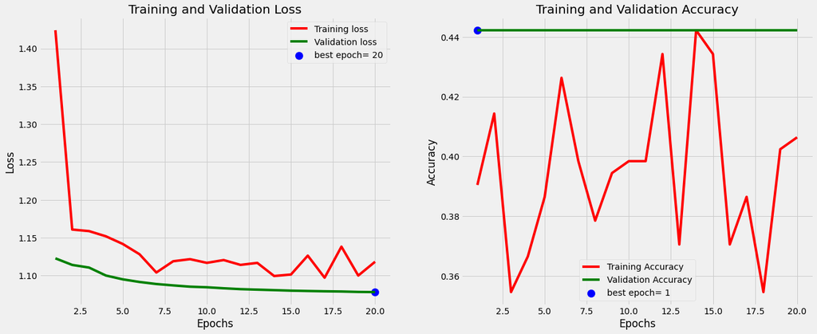

```python
def tr_plot(tr_data, start_epoch):
  #Plot the training and validation data
  tacc=tr_data.history['accuracy']
  tloss=tr_data.history['loss']
  vacc=tr_data.history['val_accuracy']
  vloss=tr_data.history['val_loss']
  Epoch_count=len(tacc)+ start_epoch
  Epochs=[]
  for i in range (start_epoch ,Epoch_count):
    Epochs.append(i+1)
  index_loss=np.argmin(vloss)# this is the epoch with the lowest validation loss
  val_lowest=vloss[index_loss]
  index_acc=np.argmax(vacc)
  acc_highest=vacc[index_acc]
  plt.style.use('fivethirtyeight')
  sc_label='best epoch= '+ str(index_loss+1 +start_epoch)
  vc_label='best epoch= '+ str(index_acc + 1+ start_epoch)
  fig,axes=plt.subplots(nrows=1, ncols=2, figsize=(20,8))
  axes[0].plot(Epochs,tloss, 'r', label='Training loss')
  axes[0].plot(Epochs,vloss,'g',label='Validation loss' )
  axes[0].scatter(index_loss+1 +start_epoch,val_lowest, s=150, c= 'blue', label=sc_label)
  axes[0].set_title('Training and Validation Loss')
  axes[0].set_xlabel('Epochs')
  axes[0].set_ylabel('Loss')
  axes[0].legend()
  axes[1].plot (Epochs,tacc,'r',label= 'Training Accuracy')
  axes[1].plot (Epochs,vacc,'g',label= 'Validation Accuracy')
  axes[1].scatter(index_acc+1 +start_epoch,acc_highest, s=150, c= 'blue', label=vc_label)
  axes[1].set_title('Training and Validation Accuracy')
  axes[1].set_xlabel('Epochs')
  axes[1].set_ylabel('Accuracy')
  axes[1].legend()
  plt.tight_layout
  plt.show()

tr_plot(history_2,0)
```

Para mejorar la segunda iteración de la CNN, le añadimos un early stopper y dropout. El dropout elimina aleatoriamente nueronas en el entrenamiento, de tal manera que las otras neuronas tiene que intentar aprender lo que las neuronas eliminadas estaban aprendiendo. Esto es un proceso en el que la red se vuelve menos sensitiva a los pesos de las neuronas, lo que resulta en una reducción de "overfitting" si hubiese. El early stopper analiza una métrica (en este caso el val_loss) e intenta quedarse con la mejor de todas lo antes posible, le añadimos un "patience" de 3 de tal manera que el si último val_loss no se ve mejorado en las 3 próximas iteraciones, este es el val_loss óptimo considerado por la red y con esto finaliza el proceso de iteración.

Además se ha modificado la función de activación a una tanh, que castiga fuertemente los valores negativos durante el entrenamiento.

```python
model_3 = models.Sequential()
model_3.add(layers.Conv2D(32, (3, 3), activation='tanh', input_shape=(50, 50, 1)))
model_3.add(layers.MaxPooling2D((2, 2)))
model_3.add(layers.Conv2D(64, (3, 3), activation='tanh'))
model_3.add(layers.MaxPooling2D((2, 2)))
```

```python
model_3.add(layers.Flatten())
model_3.add(layers.Dense(64, activation='tanh'))
model_3.add(Dropout(0.15))
model_3.add(layers.Dense(10))
```

```python
callback = tf.keras.callbacks.EarlyStopping(monitor='val_loss',mode='min',baseline=0.3, patience=3)
```

```python
model_3.compile(optimizer='adam',
              loss=tf.keras.losses.SparseCategoricalCrossentropy(from_logits=True),
              metrics=['accuracy'])

history_3 = model_3.fit(train_images, train_labels, epochs=20, callbacks=[callback],
                    validation_data=(test_images, test_labels))
```

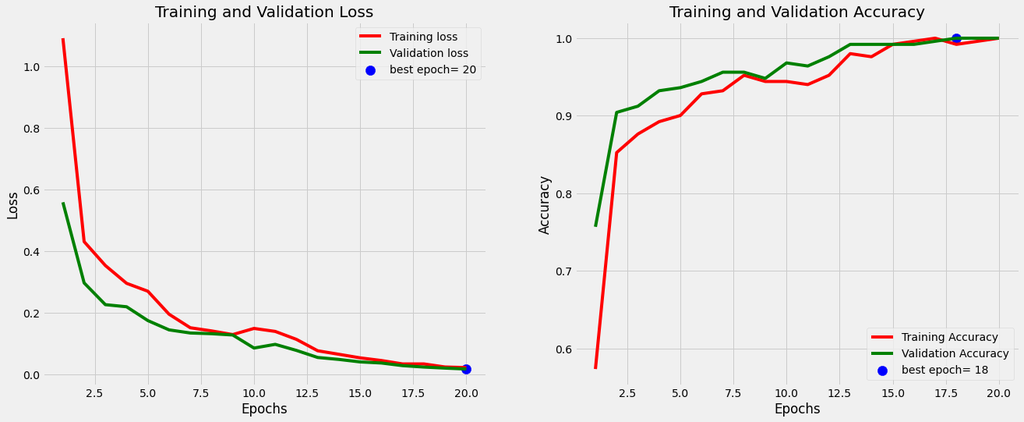

```python
def tr_plot(tr_data, start_epoch):
  #Plot the training and validation data
  tacc=tr_data.history['accuracy']
  tloss=tr_data.history['loss']
  vacc=tr_data.history['val_accuracy']
  vloss=tr_data.history['val_loss']
  Epoch_count=len(tacc)+ start_epoch
  Epochs=[]
  for i in range (start_epoch ,Epoch_count):
    Epochs.append(i+1)
  index_loss=np.argmin(vloss)# this is the epoch with the lowest validation loss
  val_lowest=vloss[index_loss]
  index_acc=np.argmax(vacc)
  acc_highest=vacc[index_acc]
  plt.style.use('fivethirtyeight')
  sc_label='best epoch= '+ str(index_loss+1 +start_epoch)
  vc_label='best epoch= '+ str(index_acc + 1+ start_epoch)
  fig,axes=plt.subplots(nrows=1, ncols=2, figsize=(20,8))
  axes[0].plot(Epochs,tloss, 'r', label='Training loss')
  axes[0].plot(Epochs,vloss,'g',label='Validation loss' )
  axes[0].scatter(index_loss+1 +start_epoch,val_lowest, s=150, c= 'blue', label=sc_label)
  axes[0].set_title('Training and Validation Loss')
  axes[0].set_xlabel('Epochs')
  axes[0].set_ylabel('Loss')
  axes[0].legend()
  axes[1].plot (Epochs,tacc,'r',label= 'Training Accuracy')
  axes[1].plot (Epochs,vacc,'g',label= 'Validation Accuracy')
  axes[1].scatter(index_acc+1 +start_epoch,acc_highest, s=150, c= 'blue', label=vc_label)
  axes[1].set_title('Training and Validation Accuracy')
  axes[1].set_xlabel('Epochs')
  axes[1].set_ylabel('Accuracy')
  axes[1].legend()
  plt.tight_layout
  plt.show()

tr_plot(history_3,0)
```

El funcionamiento de la CNN es "perfecto", ya que es capaz de diferenciar todos los casos de Covid-19 y no Covid-19 puesto que la precisión es de 1. Esto puede incidir en una sospecha de "overfitting", pero observando la evolución de la función de pérdida y de la precisión en función de los episodios, se puede concluir dado que las líneas no se separan en ningún momento, no existe "overfitting" en el modelo. Personalmente, sospechamos que el dataset está academicamente preparado.

Para intentar mejorar la tercera iteración, se añade una nueva capa convolucional.

```python
model = models.Sequential()
model.add(layers.Conv2D(32, (3, 3), activation='relu', input_shape=(50, 50, 1)))
model.add(layers.MaxPooling2D((2, 2)))
model.add(layers.Conv2D(64, (3, 3), activation='relu'))
model.add(layers.MaxPooling2D((2, 2)))
model.add(layers.Conv2D(64, (3, 3), activation='relu'))
```

```python
model.summary()
```

[output not shown]

```python
model.add(layers.Flatten())
model.add(layers.Dense(64, activation='relu'))
model.add(Dropout(0.15))
model.add(layers.Dense(10))
```

```python
model.summary()
```

[output not shown]

```python
tf.random.set_seed(2022)
```

```python
model.compile(optimizer='adam',
              loss=tf.keras.losses.SparseCategoricalCrossentropy(from_logits=True),
              metrics=['accuracy'])

history = model.fit(train_images, train_labels, epochs=20,
                    validation_data=(test_images, test_labels))
```

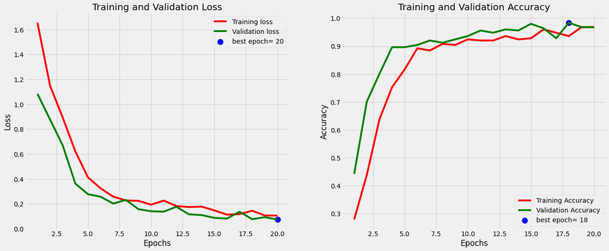

```python
def tr_plot(tr_data, start_epoch):
  #Plot the training and validation data
  tacc=tr_data.history['accuracy']
  tloss=tr_data.history['loss']
  vacc=tr_data.history['val_accuracy']
  vloss=tr_data.history['val_loss']
  Epoch_count=len(tacc)+ start_epoch
  Epochs=[]
  for i in range (start_epoch ,Epoch_count):
    Epochs.append(i+1)
  index_loss=np.argmin(vloss)# this is the epoch with the lowest validation loss
  val_lowest=vloss[index_loss]
  index_acc=np.argmax(vacc)
  acc_highest=vacc[index_acc]
  plt.style.use('fivethirtyeight')
  sc_label='best epoch= '+ str(index_loss+1 +start_epoch)
  vc_label='best epoch= '+ str(index_acc + 1+ start_epoch)
  fig,axes=plt.subplots(nrows=1, ncols=2, figsize=(20,8))
  axes[0].plot(Epochs,tloss, 'r', label='Training loss')
  axes[0].plot(Epochs,vloss,'g',label='Validation loss' )
  axes[0].scatter(index_loss+1 +start_epoch,val_lowest, s=150, c= 'blue', label=sc_label)
  axes[0].set_title('Training and Validation Loss')
  axes[0].set_xlabel('Epochs')
  axes[0].set_ylabel('Loss')
  axes[0].legend()
  axes[1].plot (Epochs,tacc,'r',label= 'Training Accuracy')
  axes[1].plot (Epochs,vacc,'g',label= 'Validation Accuracy')
  axes[1].scatter(index_acc+1 +start_epoch,acc_highest, s=150, c= 'blue', label=vc_label)
  axes[1].set_title('Training and Validation Accuracy')
  axes[1].set_xlabel('Epochs')
  axes[1].set_ylabel('Accuracy')
  axes[1].legend()
  plt.tight_layout
  plt.show()

tr_plot(history,0)
```

Los resultados son de esta iteración son muy similares al los expuestos en la iteración anterior, no hay "overfitting" por la misma razón, pero en este caso la precisión se queda en 0.98.

# Conclusiones

El mejor modelo es la tercera iteración de la CNN, ya que se obtiene una precisión del 100% sin que el modelo este sobre entrenado. Se usa la función de activación tanh para penalizar valores negativos durante el entrenamiento.

Para mejorar este modelo, se debería usar un dataset de entrenamiento y validación con un mayor número de imágenes.

```python
%%shell
jupyter nbconvert --to html //content/drive/MyDrive/colab_notebooks/Datos_no_estructurados/practica_imagen/cnn_datos_no_estructurados.ipynb
```